### First plot description

The first plot demonstrates a negatively-skewed distribution.  
It shows the increase of contributions along the time, and the closer it gets to the election, the higher the contribution gets, and even after this event, still some contributions are made.  
The months with the highest contribution were September and October, 2016.  
By November 2016 (election date was November 8), the contribution total was reduced by approximately 60%, and it went almost to zero by December.  
But it was interesting to realize that even after the election, some contributions were made.  
The contributions were increasing moderately month-by-month, with some peaks in June, September and December, 2015, with a big increase by February 2016, when the Debates got intensified.  
After the “drop-out” of some candidates (from February until May) the contribution amount decreased until May 2016, increasing in big jumps until Election Date.  
A really good guideline for the 2016 US elections can be found [here](https://www.theguardian.com/us-news/2016/nov/07/us-election-2016-complete-timeline-clinton-trump-president).  
Source: The Guardian –> “How we got here: a complete timeline of 2016’s historic US election”

### Second plot

**Contribution increase over time, by candidate**

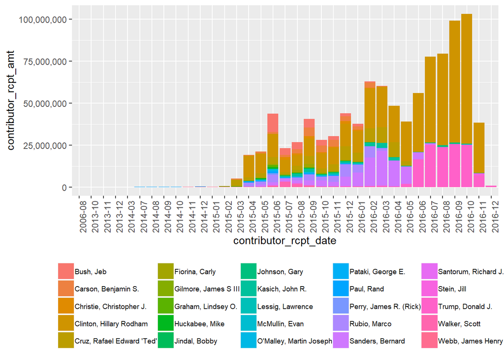

### Third plot

**Total contribution by State and Party**

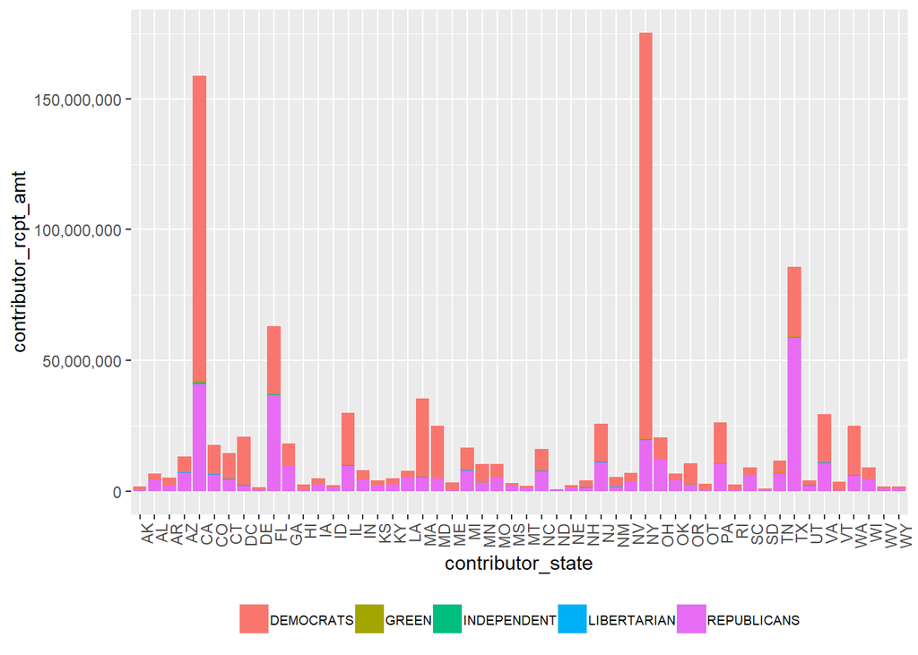

# Reflection

This was a very interesting dataset to work with, due to its importance and for the chance to find interesting insights on it. And a pleasure to see the results as well.  
Despite all these facts, it took me some time to go deep into the dataset, and understand that the data was organized by the Federal Election Commission, but there were missing values in receipt amounts, ZIP codes had incomplete data, like the contributor’s occupation and so on, but overall data was ok.  
This is an imbalanced dataset, just like almost all other datasets we will find in ERPs, census, and financial data. So, in my opinion, finding some datasets like Iris, Cars and FlightData with almost none (or zero) missing fields or invalid data are not what we will find in our regular projects.  
For me, it was a challenge to work with R, since I got used to Python and Jupyter Notebook, but after all the initial difficulties, I found it to be easier and faster to work with, and I am taking this experience to the company that I work for.  
There are a lot of opportunities laying around to work with data: sensors, census, economics, trucks and cars’ engine data and corporate data (licensed to use, naturally), just to mention a few.  
About the plots: the course gave me a good understanding about which one to use and why I should use one instead of another, depending on the data. And the audience.  
GGPlot, GGally and others took me a lot of time to understand, and I spent a lot of it trying to adjust visualization, legend and related visuals, but after that, it was great to realize the versatility of these packages, and plots are not so difficult to produce.  
The dataset did not take too much time in the EDA phase, but the plots and HTML formatting took much more than I expected. Which is ok for the first R project.  
It was required, for correlation tests, to change categorical data into numerical, but just for some analysis. The kind of this dataset can run just a few correlation tests, but with more data, a more accurate correlation can be calculated.  
I will do it again next year with the 2020 Election data, so I can compare the datasets for any new variables and contributor’s accuracy, and use this study to go deeper into other facts that could identify trends or other aspects that could affect the results.